# AnomalyDetection

## **Part 1: Preparation**

For this project, I work with a [credit card fraud detection](https://www.kaggle.com/datasets/mlg-ulb/creditcardfraud) dataset from Kaggle, consisting of transactions made by credit cards in September 2013 by European cardholders. The dataset contains only numerical input variables (`V1`, `V2`, … `V28`) which are the principal components obtained with PCA transformation (PCA will the introduced later in this course), due to confidentiality issues. The only features which have not been transformed with PCA are `Time` (seconds elapsed between each transaction and the first transaction in the dataset) and `Amount` (transaction Amount).  
This dataset contains 284807rows and 30 key features, which are not directly interpretable but contain meaningful information about the dataset.

```python
pip install wget
```

```
  Preparing metadata (setup.py) ... done
```

```python
import wget

# download the data
wget.download('https://raw.githubusercontent.com/Sabaae/Dataset/master/creditcard.csv')
```

```
'creditcard.csv'
```

```python
import pandas as pd
import numpy as np
import matplotlib.pyplot as plt
import seaborn as sns
from sklearn.model_selection import train_test_split
from sklearn.preprocessing import StandardScaler
```

```python
df = pd.read_csv('creditcard.csv')
df.describe()
```

|  | Time | V1 | V2 | V3 | V4 | V5 | V6 | V7 | V8 | V9 | ... | V21 | V22 | V23 | V24 | V25 | V26 | V27 | V28 | Amount | Class |
| --- | --- | --- | --- | --- | --- | --- | --- | --- | --- | --- | --- | --- | --- | --- | --- | --- | --- | --- | --- | --- | --- |
| count | 284807.000000 | 2.848070e+05 | 2.848070e+05 | 2.848070e+05 | 2.848070e+05 | 2.848070e+05 | 2.848070e+05 | 2.848070e+05 | 2.848070e+05 | 2.848070e+05 | ... | 2.848070e+05 | 2.848070e+05 | 2.848070e+05 | 2.848070e+05 | 2.848070e+05 | 2.848070e+05 | 2.848070e+05 | 2.848070e+05 | 284807.000000 | 284807.000000 |
| mean | 94813.859575 | 1.759061e-12 | -8.251130e-13 | -9.654937e-13 | 8.321385e-13 | 1.649999e-13 | 4.248366e-13 | -3.054600e-13 | 8.777971e-14 | -1.179749e-12 | ... | -3.405756e-13 | -5.723197e-13 | -9.725856e-13 | 1.464150e-12 | -6.987102e-13 | -5.617874e-13 | 3.332082e-12 | -3.518874e-12 | 88.349619 | 0.001727 |
| std | 47488.145955 | 1.958696e+00 | 1.651309e+00 | 1.516255e+00 | 1.415869e+00 | 1.380247e+00 | 1.332271e+00 | 1.237094e+00 | 1.194353e+00 | 1.098632e+00 | ... | 7.345240e-01 | 7.257016e-01 | 6.244603e-01 | 6.056471e-01 | 5.212781e-01 | 4.822270e-01 | 4.036325e-01 | 3.300833e-01 | 250.120109 | 0.041527 |
| min | 0.000000 | -5.640751e+01 | -7.271573e+01 | -4.832559e+01 | -5.683171e+00 | -1.137433e+02 | -2.616051e+01 | -4.355724e+01 | -7.321672e+01 | -1.343407e+01 | ... | -3.483038e+01 | -1.093314e+01 | -4.480774e+01 | -2.836627e+00 | -1.029540e+01 | -2.604551e+00 | -2.256568e+01 | -1.543008e+01 | 0.000000 | 0.000000 |
| 25% | 54201.500000 | -9.203734e-01 | -5.985499e-01 | -8.903648e-01 | -8.486401e-01 | -6.915971e-01 | -7.682956e-01 | -5.540759e-01 | -2.086297e-01 | -6.430976e-01 | ... | -2.283949e-01 | -5.423504e-01 | -1.618463e-01 | -3.545861e-01 | -3.171451e-01 | -3.269839e-01 | -7.083953e-02 | -5.295979e-02 | 5.600000 | 0.000000 |
| 50% | 84692.000000 | 1.810880e-02 | 6.548556e-02 | 1.798463e-01 | -1.984653e-02 | -5.433583e-02 | -2.741871e-01 | 4.010308e-02 | 2.235804e-02 | -5.142873e-02 | ... | -2.945017e-02 | 6.781943e-03 | -1.119293e-02 | 4.097606e-02 | 1.659350e-02 | -5.213911e-02 | 1.342146e-03 | 1.124383e-02 | 22.000000 | 0.000000 |
| 75% | 139320.500000 | 1.315642e+00 | 8.037239e-01 | 1.027196e+00 | 7.433413e-01 | 6.119264e-01 | 3.985649e-01 | 5.704361e-01 | 3.273459e-01 | 5.971390e-01 | ... | 1.863772e-01 | 5.285536e-01 | 1.476421e-01 | 4.395266e-01 | 3.507156e-01 | 2.409522e-01 | 9.104512e-02 | 7.827995e-02 | 77.165000 | 0.000000 |
| max | 172792.000000 | 2.454930e+00 | 2.205773e+01 | 9.382558e+00 | 1.687534e+01 | 3.480167e+01 | 7.330163e+01 | 1.205895e+02 | 2.000721e+01 | 1.559499e+01 | ... | 2.720284e+01 | 1.050309e+01 | 2.252841e+01 | 4.584549e+00 | 7.519589e+00 | 3.517346e+00 | 3.161220e+01 | 3.384781e+01 | 25691.160000 | 1.000000 |

8 rows × 31 columns

```python
# fraud percentage
len(df.loc[df['Class']==1])/len(df)*100
```

```
0.1727485630620034
```

```python
# non-fraud percentage
len(df.loc[df['Class']==0])/len(df)*100
```

```
99.82725143693798
```

The data is not balanced because there are far more non-fraud transactions than fraud transactions and the number of non-fraud transactions is dominating(99.827% of entire dataset)

Next, I split the dataset into a training (70%), validation (15%) and testing set (15%).

```python
### Split the data  ###
train, test = train_test_split(df, test_size=0.3, random_state=0)
val, test = train_test_split(test, test_size=0.5, random_state=0)
y_train, y_val, y_test = train['Class'], val['Class'], test['Class']
X_train = train.drop('Class', axis = 1)
X_val = val.drop('Class', axis = 1)
X_test = test.drop('Class', axis = 1)
```

Now, let's take a look at the difference in distribution for all variables between non-fraudulent and fraudulent credit card transactions:

```
Time
V1
V2
V3
V4
V5
V6
V7
V8
V9
V10
V11
V12
V13
V14
V15
V16
V17
V18
V19
V20
V21
V22
V23
V24
V25
V26
V27
V28
Amount
```

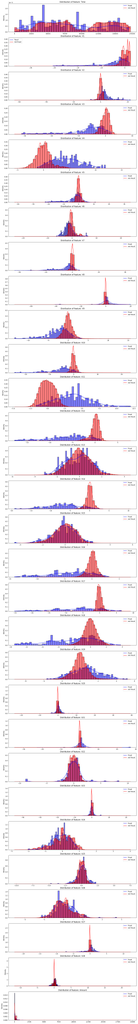

```python
import matplotlib.gridspec as gridspec
features=[f for f in df.columns if not 'Class' in f]
nplots=np.size(features)
plt.figure(figsize=(15,4*nplots))
gs = gridspec.GridSpec(nplots,1)
for i, feat in enumerate(features):
    print(feat)
    ax = plt.subplot(gs[i])
    sns.histplot(X_train[feat][y_train==1], stat="density", kde=True, color="blue", bins=50)
    sns.histplot(X_train[feat][y_train==0], stat="density", kde=True, color="red", bins=50)
    ax.legend(['fraud', 'not-fraud'],loc='best')
    ax.set_xlabel('')
    ax.set_title('Distribution of feature: ' + feat)
```

Explain how these graphs could provide meaningful information about anomaly detection using a gaussian model. **[0.5]**

These graphs illustrate the distribution for each feature and from that we can know which features are useful in distinguishing between fraud and non-fraud transactions and they should be kept. From the above graphs, features V3, V4, V9, V10, V11, V12, V14, V16, V17, V18, V19 are good to use because they have very different distribution for fraud transactions and non-fraud transactions. In contrast, features V1, V2, V5, V6, V7, V8, V13, V15, V20, V21, V22, V23, V24, V25, V26, V27, V28 have similar distribution for fraud transactions and non-fraud transactions, so they are not helpful in differentiating fraud and non-fraud transactions.

## **Part 2: Single feature model with one Gaussian distribution:**

I'll start by making a prediction using **a single feature of our dataset at a time**.

Please note that I **only use `V` features** in my model.

**a. Fitting regardless of class:**

1. Fit a single Gaussian distribution on a single feature of **the full training dataset** (both classes) using `sklearn.mixture.GaussianMixture` when `n_components=1`.
2. Compute AUC (Area under the ROC Curve) based on `sklearn.mixture.GaussianMixture.score_samples` on both the full training set and validation set (including both classes).
3. Repeat the above steps for each of the features and present your findings in a table.
4. Find the best 3 features to distinguish fraud transactions from not-fraud transactions based on the AUC of the validation set.
5. Make a prediction based on a model's scores: If the `score_samples` is lower than a threshold, I consider that transaction as a fraud. Find an optimal threshold that maximizes the F1 Score of the validation set for each of those 3 features separately.

**b. Fitting based on class:**

1. Pick 3 features that had the best AUC in Part 2a.
2. Compute AUC and F1 score when you fit a Gaussian **only on not-fraud transactions** (instead of all the transactions).
3. Compare results from parts 2a and 2b (AUC and F1 score) in a table.

**Part A**

```python
# Part a
# step 1~2
from sklearn.mixture import GaussianMixture
from sklearn.metrics import roc_auc_score, auc

# store AUC
auc_train = []
auc_val = []

for i in range(1, 29): #only use V features in model
  gm = GaussianMixture(n_components = 1, covariance_type = 'full', random_state=0) # gaussian model
  gm.fit(X_train.iloc[:,i].values.reshape(-1, 1)) #fit on single feature

  # AUC on training set
  p_train = gm.score_samples(X_train.iloc[:,i].values.reshape(-1, 1))
  auc_train.append(roc_auc_score(y_train, -1 * p_train))

  # AUC on validation set
  p_val = gm.score_samples(X_val.iloc[:, i].values.reshape(-1, 1))
  auc_val.append(roc_auc_score(y_val, -1 * p_val))
```

```python
# step 3: present findings in a table
auc_list = {'training AUC':auc_train, 'validation AUC': auc_val}
df_auc = pd.DataFrame(auc_list, index = df.columns[1:29])
df_auc
```

|  | training AUC | validation AUC |
| --- | --- | --- |
| V1 | 0.705102 | 0.694811 |
| V2 | 0.837499 | 0.837800 |
| V3 | 0.876537 | 0.838364 |
| V4 | 0.892103 | 0.888283 |
| V5 | 0.771825 | 0.786857 |
| V6 | 0.734380 | 0.673559 |
| V7 | 0.862967 | 0.867423 |
| V8 | 0.773238 | 0.774130 |
| V9 | 0.802874 | 0.776739 |
| V10 | 0.913600 | 0.905959 |
| V11 | 0.897175 | 0.882058 |
| V12 | 0.920180 | 0.837909 |
| V13 | 0.572152 | 0.561798 |
| V14 | 0.952459 | 0.938073 |
| V15 | 0.514764 | 0.509647 |
| V16 | 0.902137 | 0.882852 |
| V17 | 0.934852 | 0.881858 |
| V18 | 0.808030 | 0.785790 |
| V19 | 0.741874 | 0.770560 |
| V20 | 0.734692 | 0.686071 |
| V21 | 0.833521 | 0.764318 |
| V22 | 0.561287 | 0.493503 |
| V23 | 0.696326 | 0.660997 |
| V24 | 0.469229 | 0.497913 |
| V25 | 0.574918 | 0.521330 |
| V26 | 0.503272 | 0.516492 |
| V27 | 0.835479 | 0.766315 |
| V28 | 0.814201 | 0.794233 |

```python
# step 4: best 3 features based on validation AUC
df_auc.nlargest(3, 'validation AUC')
```

|  | training AUC | validation AUC |
| --- | --- | --- |
| V14 | 0.952459 | 0.938073 |
| V10 | 0.913600 | 0.905959 |
| V4 | 0.892103 | 0.888283 |

The best 3 features are V14, V10 and V4.

```python
# step 5: find optimal threshold based on F1 score
from sklearn.metrics import f1_score

# store threshold and max f1 score for 3 features
max_tr = []
max_f1 = []

for feature in [4, 10, 14]:
  gm = GaussianMixture(n_components = 1, covariance_type = 'full', random_state=0) # gaussian model
  gm.fit(X_train.iloc[:,feature].values.reshape(-1, 1)) #fit on single feature
  p_val = gm.score_samples(X_val.iloc[:,feature].values.reshape(-1, 1))
  f1_list = [] # store all F1 score
  threshold = [] # store all threshold

  # use method 2 from tutorial2
  for i in [1, 10, 15, 20, 30, 50, 70, 80, 100, 120, 130, 150, 170, 200]:
   tr = sorted(p_val)[i] #We sort the points by probability
   y_pred = [0 if (p > tr) else 1 for p in p_val]
   f1_list.append(f1_score(y_val, y_pred))
   threshold.append(tr)

  max_f1.append(max(f1_list))
  max_tr.append(threshold[pd.Series(f1_list).idxmax()])
```

```python
f1_list = {'Best F1 score':max_f1, 'Optimal Threshold': max_tr}
df_f1 = pd.DataFrame(f1_list, index = ['V4', 'V10', 'V14'])
df_f1
```

|  | Best F1 score | Optimal Threshold |
| --- | --- | --- |
| V4 | 0.347826 | -8.611596 |
| V10 | 0.250000 | -57.727529 |
| V14 | 0.576271 | -20.817681 |

For my method of finding optimal threshold, I looped through each possible threshold in a predefined set and computed the corresponding prediction matrix. For each possible threshold, when computing the prediction matrix, I looped through each value in *p_val*, which takes n since the length of *p_val* equals to the length of validation set. I also used function *sorted()* to sort *p_val*, which takes nlogn on average. Assuming assignment and comparison takes constant time, then runtime for each threshold is n+nlogn. So the total runtime for all threshold is 14*(n+nlogn) since there are 14 possible thresholds. So the complexity of my method is **O(nlogn)**

**Part B**

Step 1: According to step 4, my best 3 features are V14, V10, V4

```python
# Part b
# step 1
df_auc.nlargest(3, 'validation AUC')
```

|  | training AUC | validation AUC |
| --- | --- | --- |
| V14 | 0.952459 | 0.938073 |
| V10 | 0.913600 | 0.905959 |
| V4 | 0.892103 | 0.888283 |

```python
# step 2
# select only non-fraud class
train_nonFraud = train.copy()
train_nonFraud = train_nonFraud.loc[train_nonFraud['Class']==0]
X_nonFraud = train_nonFraud.drop('Class', axis = 1)

# store AUC
auc_train_B = []
auc_val_B = []
# store best threshold and max f1 score for 3 features
max_tr_B = []
max_f1_B = []

for feature in [4, 10, 14]:
  gm = GaussianMixture(n_components = 1, covariance_type = 'full', random_state=0) # gaussian model
  gm.fit(X_nonFraud.iloc[:,feature].values.reshape(-1, 1)) #fit on single feature

  # AUC on training set
  p_train = gm.score_samples(X_train.iloc[:,feature].values.reshape(-1, 1))
  auc_train_B.append(roc_auc_score(y_train, -1 * p_train))

  # AUC on validation set
  p_val = gm.score_samples(X_val.iloc[:, feature].values.reshape(-1, 1))
  auc_val_B.append(roc_auc_score(y_val, -1 * p_val))

  f1_list = [] # store all validation F1 score
  threshold = [] # store all threshold

  # F1 score & threshold
  for i in [1, 10, 15, 20, 30, 50, 70, 80, 100, 120, 130, 150, 170, 200]:
   tr = sorted(p_val)[i] #We sort the points by probability
   y_pred = [0 if (p > tr) else 1 for p in p_val]
   f1_list.append(f1_score(y_val, y_pred))
   threshold.append(tr)

  max_f1_B.append(max(f1_list))
  max_tr_B.append(threshold[pd.Series(f1_list).idxmax()])
```

```python
# step 3
auc_train_A = []
auc_val_A = []
for i in [3, 9, 13]:
  auc_train_A.append(auc_train[i])
  auc_val_A.append(auc_val[i])

total_list = {'(Part A)F1 score':max_f1,'(Part B)F1 score':max_f1_B, '(Part A)Optimal Threshold': max_tr,
              '(Part B)Optimal Threshold': max_tr_B, '(Part A)training AUC':auc_train_A, '(Part B)training AUC':auc_train_B,
              '(Part A)validation AUC': auc_val_A, '(Part B)validation AUC': auc_val_B}
df_total = pd.DataFrame(total_list, index = ['V4', 'V10', 'V14'])
df_total
```

|  | (Part A)F1 score | (Part B)F1 score | (Part A)Optimal Threshold | (Part B)Optimal Threshold | (Part A)training AUC | (Part B)training AUC | (Part A)validation AUC | (Part B)validation AUC |
| --- | --- | --- | --- | --- | --- | --- | --- | --- |
| V4 | 0.347826 | 0.347826 | -8.611596 | -8.789064 | 0.892103 | 0.892612 | 0.888283 | 0.888803 |
| V10 | 0.250000 | 0.250000 | -57.727529 | -62.474651 | 0.913600 | 0.913558 | 0.905959 | 0.905900 |
| V14 | 0.576271 | 0.576271 | -20.817681 | -23.547542 | 0.952459 | 0.952599 | 0.938073 | 0.938072 |

Step 4: They are very similar. This is because the data set is imbalanced. There are 0.173% fraud transaction and 99.827% non-fraud transactions. The large amount of non-fraud transactions dominate results when fitting the model. So with or without the non-fraud transactions does not make a difference in model fitting in such case.

## **Part 3: Multiple feature model with one Gaussian distribution:**

This part is similar to Part 2, but I will pick multiple features and **visually** set the number of components.

a. 2D plot:

1. Pick two features (say, f1 and f2).
2. Scatter plot (plt.scatter) those features on a figure (f1 on the x-axis and f2 on the y-axis).
3. Color the data points based on their class (not-fraud blue and fraud red).
4. Based on my plots, decide how many Gaussian components (`n_components`) you need to fit the data (focus on valid transactions). Explain.
5. Fit my Gaussian model on all the data points.
6. Compute AUC on both training and validation sets
7. Pick 3 new pairs of features and repeat steps 2 to 6.
8. For each pair, find a threshold to maximize my validation set F1 Score.
9. For each pair, plot a figure similar to step 3 and put a circle around outliers based on my threshold (use the code of the similar figure in the tutorial)

```python
from matplotlib.colors import ListedColormap

# helper function for scatter plot(step 1~3)
def plot_scatter(feature1, feature2):
  colors = ListedColormap(['b','r'])
  classes = ['Non-fraud', 'Fraud']
  scatter = plt.scatter(X_train[feature1], X_train[feature2],marker="x", c=y_train, cmap=colors)
  plt.legend(handles=scatter.legend_elements()[0], labels=classes)
  plt.xlabel(feature1)
  plt.ylabel(feature2)
  plt.show()

# helper function for fiting Gaussian model and compute AUC(step 5~8)
def compute_auc(feature1 , feature2, num_component=1):
  feature_list = [feature1, feature2]

  gm = GaussianMixture(n_components = num_component, covariance_type = 'full', random_state=0) # gaussian model
  gm.fit(X_train[feature_list].values) # fit model

  # AUC on training set
  p_train = gm.score_samples(X_train[feature_list].values)
  auc_train = roc_auc_score(y_train, -1 * p_train)

  # AUC on validation set
  p_val = gm.score_samples(X_val[feature_list].values)
  auc_val = roc_auc_score(y_val, -1 * p_val)

  # F1 score & threshold
  f1_list = [] # store all F1 score
  threshold = [] # store all threshold
  for i in [1, 10, 15, 20, 30, 50, 70, 80, 100, 120, 130, 150, 170, 200]:
   tr = sorted(p_val)[i] #We sort the points by probability
   y_pred = [0 if (p > tr) else 1 for p in p_val]
   f1_list.append(f1_score(y_val, y_pred))
   threshold.append(tr)

  max_f1 = max(f1_list)
  max_tr = threshold[pd.Series(f1_list).idxmax()]

  # plot table
  report_table = {'training AUC':auc_train, 'validation AUC': auc_val,'Max F1 score':max_f1, 'Optimal Threshold': max_tr}
  df_report = pd.DataFrame(report_table, index = [feature1+'&'+feature2])
  return df_report

# helper function for scatter plot with outliers(step 9)
def plot_scatter_outlier(feature1, feature2, num_component=1, threshold = 1):
  colors = ListedColormap(['b','r'])
  classes = ['Non-fraud', 'Fraud']

  # find outliers
  feature_list = [feature1, feature2]
  gm = GaussianMixture(n_components = num_component, covariance_type = 'full', random_state=0) # gaussian model
  gm.fit(X_train[feature_list].values) # fit model
  p = gm.score_samples(X_train[feature_list].values)
  outliers = np.nonzero(p<threshold)[0]

  plt.scatter(X_train[feature1], X_train[feature2],marker="x", c=y_train, cmap=colors)
  plt.scatter(X_train.values[outliers, X_train.columns.get_loc(feature1)], X_train.values[outliers, X_train.columns.get_loc(feature2)],
              marker="o", facecolor= "none", edgecolor="black", s=50)
  plt.xlabel(feature1)
  plt.ylabel(feature2)
  plt.show()
```

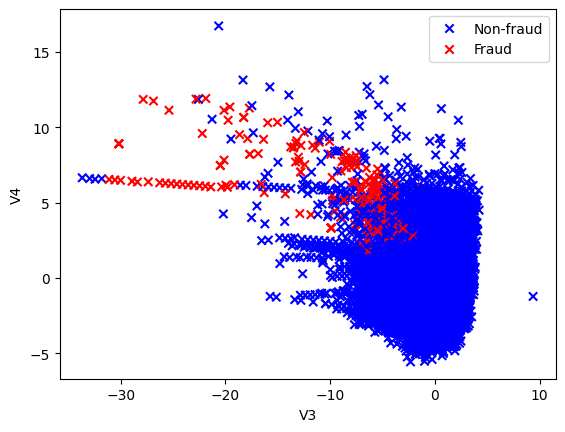

```python
# First pair: V3 & V4
plot_scatter('V3', 'V4')  # step 1~3
```

From the aboved graph, if we only focus on non-fraud transactions, then there is one major cluster in the graph. So I think component number = 1 is reasonable for V3 and V4 pair.

```python
compute_auc('V3', 'V4', 1)  # step 5~8
```

|  | training AUC | validation AUC | Max F1 score | Optimal Threshold |
| --- | --- | --- | --- | --- |
| V3&V4 | 0.922684 | 0.912418 | 0.297619 | -16.292817 |

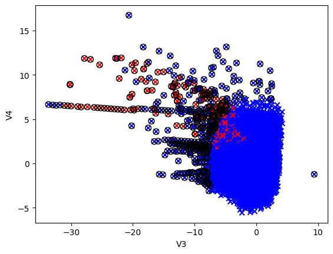

```python
plot_scatter_outlier('V3', 'V4', num_component=1, threshold = -16.292817)  # step 9
```

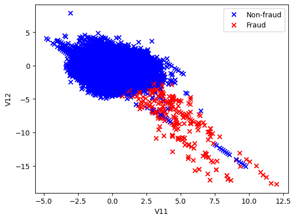

```python
# Second pair: V11 & V12
plot_scatter('V11', 'V12')  # step 1~3
```

From the aboved graph, if we only focus on non-fraud transactions, then there is one major cluster in the graph. So I think component number = 1 is reasonable for V11 and V12 pair.

```python
compute_auc('V11', 'V12', 1)  # step 5~8
```

|  | training AUC | validation AUC | Max F1 score | Optimal Threshold |
| --- | --- | --- | --- | --- |
| V11&V12 | 0.924492 | 0.8858 | 0.644068 | -14.718283 |

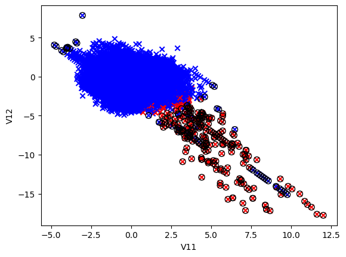

```python
plot_scatter_outlier('V11', 'V12', num_component=1, threshold = -14.718283)  # step 9
```

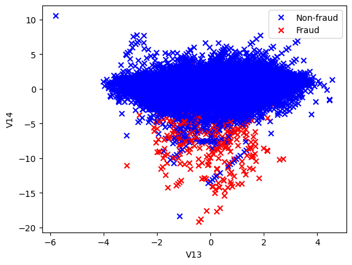

```python
# Third pair: V13 & V14
plot_scatter('V13', 'V14')  # step 1~3
```

From the aboved graph, if we only focus on non-fraud transactions, then there is one major cluster in the graph. So I think component number = 1 is reasonable for V13 and V14 pair.

```python
compute_auc('V13', 'V14', 1)  # step 5~8
```

|  | training AUC | validation AUC | Max F1 score | Optimal Threshold |
| --- | --- | --- | --- | --- |
| V13&V14 | 0.955253 | 0.929584 | 0.559322 | -22.279318 |

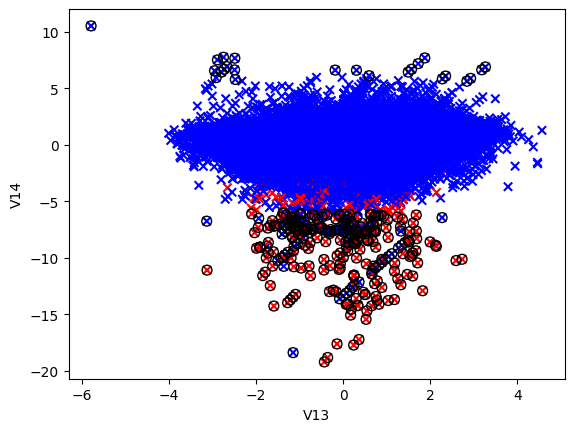

```python
plot_scatter_outlier('V13', 'V14', num_component=1, threshold = -22.279318)  # step 9
```

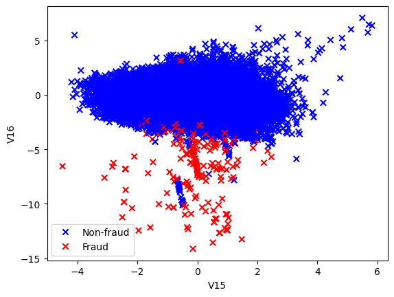

```python
# Fourth pair: V15 & V16
plot_scatter('V15', 'V16')  # step 1~3
```

From the aboved graph, if we only focus on non-fraud transactions, then there is one major cluster in the graph. So I think component number = 1 is reasonable for V15 and V16 pair.

```python
compute_auc('V15', 'V16', 1)  # step 5~8
```

|  | training AUC | validation AUC | Max F1 score | Optimal Threshold |
| --- | --- | --- | --- | --- |
| V15&V16 | 0.899128 | 0.844167 | 0.474576 | -12.360804 |

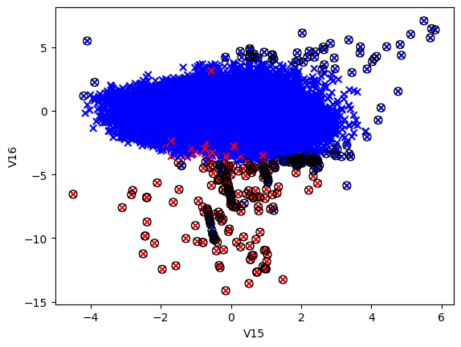

```python
plot_scatter_outlier('V15', 'V16', num_component=1, threshold = -12.360804)  # step 9
```

## **Part 4: Single feature model with two Gaussian distributions.**

Now I will use two different distributions for fraud and not-fraud transactions.

1. Fit a Gaussian distribution ($G_1$) on a feature of **not-fraud transactions** using `sklearn.mixture.GaussianMixture` when `n_components=1`.
2. Fit another Gaussian distribution ($G_2$) on the same feature but for **fraud transactions** using `sklearn.mixture.GaussianMixture` when `n_components=1`.
3. Compute the score samples ($S$) for both $G_1$ and $G_2$ on the **validation set** to get $S_1$ and $S_2$, respectively.
4. Find an optimal $c$ (a real number) that maximizes validation set F1 Score for a model such that if $S_1 < c \times S_2$, the transaction is classified as an anomaly. For example, if $c=1$ we could say that if $S_2$ is greater than $S_1$, ($S_1$<$S_2$) then the transaction is an anomaly (the transaction belongs to the $G_2$ distribution which represents fraud transactions).
5. Repeat the steps above for all the features. Find the best F1 Score for training and validation.

```python
# Step 1~4: do it for feature V14

# prepare non-fraud & fraud training set
train_part4 = train.copy()
train_part4 = train_part4.drop(['Time', 'Amount'], axis = 1)  # remove Time & Amount
# non-fraud dataset
train_nonFraud = train_part4.loc[train_part4['Class']==0]
X_nonFraud = train_nonFraud.drop('Class', axis = 1)
# fraud dataset
train_fraud = train_part4.loc[train_part4['Class']==1]
X_fraud = train_fraud.drop('Class', axis = 1)

# try for feature V14
gm1 = GaussianMixture(n_components = 1, covariance_type = 'full', random_state=0) # gaussian model
gm1.fit(X_nonFraud.iloc[:,13].values.reshape(-1, 1)) # fit G1
gm2 = GaussianMixture(n_components = 1, covariance_type = 'full', random_state=0) # gaussian model
gm2.fit(X_fraud.iloc[:,13].values.reshape(-1, 1)) # fit G2

# score samples on validation set
s1 = gm1.score_samples(X_val.iloc[:,13].values.reshape(-1, 1))
s2 = gm2.score_samples(X_val.iloc[:,13].values.reshape(-1, 1))

# optimal c & validation F1 score
f1_list = [] # store all F1 score
c_list = [] # store all c
possible_range = [x * 0.1 for x in range(0, 100)]
for c in possible_range:
  y_pred = [0 if (s1[index] >= c*s2[index]) else 1 for index in range(0, len(s1))]
  f1_list.append(f1_score(y_val, y_pred))
  c_list.append(c)

max_f1 = max(f1_list)
optimal_c = c_list[pd.Series(f1_list).idxmax()]

# score samples on training set
s1_train = gm1.score_samples(X_train.iloc[:,13].values.reshape(-1, 1))
s2_train = gm2.score_samples(X_train.iloc[:,13].values.reshape(-1, 1))
# training F1 score
y_pred = [0 if (s1_train[index] >= optimal_c*s2_train[index]) else 1 for index in range(0, len(s1_train))]
best_f1_train = f1_score(y_train, y_pred)

report_part4 = {'training F1': best_f1_train, 'validation F1': max_f1,'Best c':optimal_c}
df_part4 = pd.DataFrame(report_part4, index = ['V14'])
df_part4
```

|  | training F1 | validation F1 | Best c |
| --- | --- | --- | --- |
| V14 | 0.006047 | 0.007246 | 1.7 |

```python
# Step 5: repeat for all features

# store training & validation F1 score, c for all features
best_f1 = []
best_c = []
best_f1_train = []

for i in range(0, 28):  # loop through each feature
  gm1 = GaussianMixture(n_components = 1, covariance_type = 'full', random_state=0) # gaussian model
  gm1.fit(X_nonFraud.iloc[:,i].values.reshape(-1, 1)) # fit G1
  gm2 = GaussianMixture(n_components = 1, covariance_type = 'full', random_state=0) # gaussian model
  gm2.fit(X_fraud.iloc[:,i].values.reshape(-1, 1)) # fit G2

  # score samples on validation set
  s1 = gm1.score_samples(X_val.iloc[:,i].values.reshape(-1, 1))
  s2 = gm2.score_samples(X_val.iloc[:,i].values.reshape(-1, 1))

  # optimal c & validation F1 score
  f1_list = [] # store all F1 score
  c_list = [] # store all c
  possible_range = [x * 0.1 for x in range(0, 100)]
  for c in possible_range:
   y_pred = [0 if (s1[index] >= c*s2[index]) else 1 for index in range(0, len(s1))]
   f1_list.append(f1_score(y_val, y_pred))
   c_list.append(c)

  max_f1 = max(f1_list)
  optimal_c = c_list[pd.Series(f1_list).idxmax()]
  best_f1.append(max_f1)
  best_c.append(optimal_c)

  # score samples on training set
  s1_train = gm1.score_samples(X_train.iloc[:,i].values.reshape(-1, 1))
  s2_train = gm2.score_samples(X_train.iloc[:,i].values.reshape(-1, 1))
  # training F1 score
  y_pred = [0 if (s1_train[index] >= optimal_c*s2_train[index]) else 1 for index in range(0, len(s1_train))]
  best_f1_train.append(f1_score(y_train, y_pred))
```

```python
report_table = {'training F1': best_f1_train, 'validation F1': best_f1,'Best c':best_c}
df_report = pd.DataFrame(report_table, index = X_nonFraud.columns)
df_report
```

|  | training F1 | validation F1 | Best c |
| --- | --- | --- | --- |
| V1 | 0.003456 | 0.003132 | 9.8 |
| V2 | 0.124138 | 0.097087 | 2.9 |
| V3 | 0.050018 | 0.046901 | 2.4 |
| V4 | 0.161551 | 0.163934 | 2.1 |
| V5 | 0.262548 | 0.346154 | 3.1 |
| V6 | 0.122324 | 0.137255 | 2.5 |
| V7 | 0.051421 | 0.033003 | 2.5 |
| V8 | 0.194690 | 0.182857 | 6.4 |
| V9 | 0.029209 | 0.024615 | 1.4 |
| V10 | 0.261343 | 0.224299 | 3.6 |
| V11 | 0.073983 | 0.058300 | 1.2 |
| V12 | 0.407477 | 0.396226 | 2.4 |
| V13 | 0.061829 | 0.050787 | 1.2 |
| V14 | 0.006047 | 0.007246 | 1.7 |
| V15 | 0.256917 | 0.262626 | 1.3 |
| V16 | 0.005263 | 0.027027 | 4.4 |
| V17 | 0.518634 | 0.563636 | 4.4 |
| V18 | 0.670471 | 0.694215 | 4.1 |
| V19 | 0.129693 | 0.130841 | 2.8 |
| V20 | 0.036199 | 0.068182 | 3.1 |
| V21 | 0.015944 | 0.008850 | 0.5 |
| V22 | 0.042799 | 0.037037 | 1.7 |
| V23 | 0.036334 | 0.007722 | 2.9 |
| V24 | 0.002507 | 0.003297 | 1.7 |
| V25 | 0.003824 | 0.003338 | 0.4 |
| V26 | 0.003996 | 0.003563 | 0.9 |
| V27 | 0.002690 | 0.004133 | 0.7 |
| V28 | 0.070676 | 0.062500 | 2.7 |

```python
# the feature and its c with highest validation F1
df_report.nlargest(1, 'validation F1')
```

|  | training F1 | validation F1 | Best c |
| --- | --- | --- | --- |
| V18 | 0.670471 | 0.694215 | 4.1 |

```python
# the feature and its c with highest training F1
df_report.nlargest(1, 'training F1')
```

|  | training F1 | validation F1 | Best c |
| --- | --- | --- | --- |
| V18 | 0.670471 | 0.694215 | 4.1 |

The overall best training F1 score is 0.670471 and overall best validation F1 score is 0.694215 for feature V18 with c = 4.1

## **Part 5: Multivariate and Mixture of Gaussians Distribution**

I now want to build an outlier detection model that performs well in terms of F1 score.

**Model 1: all features, both classes, single component, 1 Gaussian**

```python
### YOUR CODE HERE ###
# model 1

# prepare data
X_train_new = X_train.copy()
X_train_new = X_train_new.drop(['Time', 'Amount'], axis = 1)
X_val_new = X_val.copy()
X_val_new = X_val_new.drop(['Time', 'Amount'], axis = 1)

gm = GaussianMixture(n_components = 1, covariance_type = 'full', random_state=0) # gaussian model
gm.fit(X_train_new.iloc[:,:].values) #fit on all feature

# AUC on training set
p_train = gm.score_samples(X_train_new.iloc[:,:].values)
auc_train = roc_auc_score(y_train, -1 * p_train)

# AUC on validation set
p_val = gm.score_samples(X_val_new.iloc[:, :].values)
auc_val = roc_auc_score(y_val, -1 * p_val)

f1_list = [] # store all F1 score
threshold = [] # store all threshold

# best validation F1 score & best threshold
for i in [1, 10, 15, 20, 30, 50, 70, 80, 100, 120, 130, 150, 170, 200]:
  tr = sorted(p_val)[i] #We sort the points by probability
  y_pred = [0 if (p > tr) else 1 for p in p_val]
  f1_list.append(f1_score(y_val, y_pred))
  threshold.append(tr)

max_f1 = max(f1_list)
max_tr = threshold[pd.Series(f1_list).idxmax()]

# training F1 score
y_pred_train = [0 if (p > tr) else 1 for p in p_train]
max_f1_train = f1_score(y_train, y_pred_train)

# results
table1 = {'training AUC': auc_train, 'validation AUC': auc_val,'training F1': max_f1_train, 'validation F1': max_f1, 'best threshold': max_tr}
df1 = pd.DataFrame(table1, index = ['V1~V28'])
df1
```

|  | training AUC | validation AUC | training F1 | validation F1 | best threshold |
| --- | --- | --- | --- | --- | --- |
| V1~V28 | 0.953477 | 0.930669 | 0.225529 | 0.244898 | -722.204679 |

**Model 2: all features, Non-fraud class, single component, 1 Gaussian**

```python
# model 2

# only non-fraud data
train_nonFraud = train.copy()
train_nonFraud = train_nonFraud.loc[train_nonFraud['Class']==0]
X_nonFraud = train_nonFraud.drop(['Class', 'Time', 'Amount'], axis = 1)

gm = GaussianMixture(n_components = 1, covariance_type = 'full', random_state=0) # gaussian model
gm.fit(X_nonFraud.iloc[:,:].values) #fit on all feature

# AUC on training set
p_train = gm.score_samples(X_train_new.iloc[:,:].values)
auc_train = roc_auc_score(y_train, -1 * p_train)

# AUC on validation set
p_val = gm.score_samples(X_val_new.iloc[:, :].values)
auc_val = roc_auc_score(y_val, -1 * p_val)

f1_list = [] # store all F1 score
threshold = [] # store all threshold

# best validation F1 score & best threshold
for i in [1, 10, 15, 20, 30, 50, 70, 80, 100, 120, 130, 150, 170, 200]:
  tr = sorted(p_val)[i] #We sort the points by probability
  y_pred = [0 if (p > tr) else 1 for p in p_val]
  f1_list.append(f1_score(y_val, y_pred))
  threshold.append(tr)

max_f1 = max(f1_list)
max_tr = threshold[pd.Series(f1_list).idxmax()]

# training F1 score
y_pred_train = [0 if (p > tr) else 1 for p in p_train]
max_f1_train = f1_score(y_train, y_pred_train)

# results
table2 = {'training AUC': auc_train, 'validation AUC': auc_val,'training F1': max_f1_train, 'validation F1': max_f1, 'best threshold': max_tr}
df2 = pd.DataFrame(table2, index = ['V1~V28'])
df2
```

|  | training AUC | validation AUC | training F1 | validation F1 | best threshold |
| --- | --- | --- | --- | --- | --- |
| V1~V28 | 0.958321 | 0.935441 | 0.419033 | 0.508475 | -753.209412 |

**Model 3: 3 features(V14, V10, V4), both classes, single component, 1 Gaussian**

I choose these 3 features because they have the top 3 highest validation AUC and are the best 3 features from part 2.

```python
# model 3
features = ['V14', 'V10', 'V4']
gm = GaussianMixture(n_components = 1, covariance_type = 'full', random_state=0) # gaussian model
gm.fit(X_train_new[features].values) #fit on 3 features

# AUC on training set
p_train = gm.score_samples(X_train_new[features].values)
auc_train = roc_auc_score(y_train, -1 * p_train)

# AUC on validation set
p_val = gm.score_samples(X_val_new[features].values)
auc_val = roc_auc_score(y_val, -1 * p_val)

f1_list = [] # store all F1 score
threshold = [] # store all threshold

# best validation F1 score & best threshold
for i in [1, 10, 15, 20, 30, 50, 70, 80, 100, 120, 130, 150, 170, 200]:
  tr = sorted(p_val)[i] #We sort the points by probability
  y_pred = [0 if (p > tr) else 1 for p in p_val]
  f1_list.append(f1_score(y_val, y_pred))
  threshold.append(tr)

max_f1 = max(f1_list)
max_tr = threshold[pd.Series(f1_list).idxmax()]

# training F1 score
y_pred_train = [0 if (p > tr) else 1 for p in p_train]
max_f1_train = f1_score(y_train, y_pred_train)

# results
table3 = {'training AUC': auc_train, 'validation AUC': auc_val,'training F1': max_f1_train, 'validation F1': max_f1, 'best threshold': max_tr}
df3 = pd.DataFrame(table3, index = ['V14, V10, V4'])
df3
```

|  | training AUC | validation AUC | training F1 | validation F1 | best threshold |
| --- | --- | --- | --- | --- | --- |
| V14, V10, V4 | 0.963268 | 0.948397 | 0.349252 | 0.405797 | -46.487406 |

**Model 4: 3 features(V14, V10, V4), Non-fraud class, single component, 1 Gaussian**

```python
# model 4
features = ['V14', 'V10', 'V4']
gm = GaussianMixture(n_components = 1, covariance_type = 'full', random_state=0) # gaussian model
gm.fit(X_nonFraud[features].values) #fit on 3 features

# AUC on training set
p_train = gm.score_samples(X_train_new[features].values)
auc_train = roc_auc_score(y_train, -1 * p_train)

# AUC on validation set
p_val = gm.score_samples(X_val_new[features].values)
auc_val = roc_auc_score(y_val, -1 * p_val)

f1_list = [] # store all F1 score
threshold = [] # store all threshold

# best validation F1 score & best threshold
for i in [1, 10, 15, 20, 30, 50, 70, 80, 100, 120, 130, 150, 170, 200]:
  tr = sorted(p_val)[i] #We sort the points by probability
  y_pred = [0 if (p > tr) else 1 for p in p_val]
  f1_list.append(f1_score(y_val, y_pred))
  threshold.append(tr)

max_f1 = max(f1_list)
max_tr = threshold[pd.Series(f1_list).idxmax()]

# training F1 score
y_pred_train = [0 if (p > tr) else 1 for p in p_train]
max_f1_train = f1_score(y_train, y_pred_train)

# results
table4 = {'training AUC': auc_train, 'validation AUC': auc_val,'training F1': max_f1_train, 'validation F1': max_f1, 'best threshold': max_tr}
df4 = pd.DataFrame(table4, index = ['V14, V10, V4'])
df4
```

|  | training AUC | validation AUC | training F1 | validation F1 | best threshold |
| --- | --- | --- | --- | --- | --- |
| V14, V10, V4 | 0.964665 | 0.949074 | 0.37 | 0.434783 | -49.485612 |

**Model 5: 3 features(V14, V10, V4), single component for both classes, 2 Gaussians**

```python
# model 5
features = ['V14', 'V10', 'V4']
gm1 = GaussianMixture(n_components = 1, covariance_type = 'full', random_state=0) # gaussian model
gm1.fit(X_nonFraud[features].values) # fit G1
gm2 = GaussianMixture(n_components = 1, covariance_type = 'full', random_state=0) # gaussian model
gm2.fit(X_fraud[features].values) # fit G2

# score samples on validation set
s1 = gm1.score_samples(X_val_new[features].values)
s2 = gm2.score_samples(X_val_new[features].values)

# optimal c & validation F1 score
f1_list = [] # store all F1 score
c_list = [] # store all c
possible_range = [x * 0.1 for x in range(0, 100)]
for c in possible_range:
  y_pred = [0 if (s1[index] >= c*s2[index]) else 1 for index in range(0, len(s1))]
  f1_list.append(f1_score(y_val, y_pred))
  c_list.append(c)

max_f1 = max(f1_list)
optimal_c = c_list[pd.Series(f1_list).idxmax()]

# score samples on training set
s1_train = gm1.score_samples(X_train_new[features].values)
s2_train = gm2.score_samples(X_train_new[features].values)

# training F1 score
y_pred = [0 if (s1_train[index] >= optimal_c*s2_train[index]) else 1 for index in range(0, len(s1_train))]
best_f1_train = f1_score(y_train, y_pred)

# results
table5 = {'training AUC': 'N/A', 'validation AUC': 'N/A','training F1': best_f1_train, 'validation F1': max_f1,'best c':optimal_c}
df5 = pd.DataFrame(table5, index = ['V14, V10, V4'])
df5
```

|  | training AUC | validation AUC | training F1 | validation F1 | best c |
| --- | --- | --- | --- | --- | --- |
| V14, V10, V4 | N/A | N/A | 0.674121 | 0.611111 | 6.1 |

**Model 6: 3 features(V14, V10, V4), 1 component for non-fraud class and 2 components for fraud class, 2 Gaussians**

```python
# model 6
features = ['V14', 'V10', 'V4']
gm1 = GaussianMixture(n_components = 1, covariance_type = 'full', random_state=0) # gaussian model
gm1.fit(X_nonFraud[features].values) # fit G1
gm2 = GaussianMixture(n_components = 2, covariance_type = 'full', random_state=0) # gaussian model
gm2.fit(X_fraud[features].values) # fit G2

# score samples on validation set
s1 = gm1.score_samples(X_val_new[features].values)
s2 = gm2.score_samples(X_val_new[features].values)

# optimal c & validation F1 score
f1_list = [] # store all F1 score
c_list = [] # store all c
possible_range = [x * 0.1 for x in range(0, 100)]
for c in possible_range:
  y_pred = [0 if (s1[index] >= c*s2[index]) else 1 for index in range(0, len(s1))]
  f1_list.append(f1_score(y_val, y_pred))
  c_list.append(c)

max_f1 = max(f1_list)
optimal_c = c_list[pd.Series(f1_list).idxmax()]

# score samples on training set
s1_train = gm1.score_samples(X_train_new[features].values)
s2_train = gm2.score_samples(X_train_new[features].values)

# training F1 score
y_pred = [0 if (s1_train[index] >= optimal_c*s2_train[index]) else 1 for index in range(0, len(s1_train))]
best_f1_train = f1_score(y_train, y_pred)

# results
table6 = {'training AUC': 'N/A', 'validation AUC': 'N/A', 'training F1': best_f1_train, 'validation F1': max_f1,'best c':optimal_c}
df6 = pd.DataFrame(table6, index = ['V14, V10, V4'])
df6
```

|  | training AUC | validation AUC | training F1 | validation F1 | best c |
| --- | --- | --- | --- | --- | --- |
| V14, V10, V4 | N/A | N/A | 0.762319 | 0.784 | 4.0 |

**Model 7: 3 features(V14, V10, V4), 1 component for non-fraud class and 3 components for fraud class, 2 Gaussians**

```python
# model 7
features = ['V14', 'V10', 'V4']
gm1 = GaussianMixture(n_components = 1, covariance_type = 'full', random_state=0) # gaussian model
gm1.fit(X_nonFraud[features].values) # fit G1
gm2 = GaussianMixture(n_components = 3, covariance_type = 'full', random_state=0) # gaussian model
gm2.fit(X_fraud[features].values) # fit G2

# score samples on validation set
s1 = gm1.score_samples(X_val_new[features].values)
s2 = gm2.score_samples(X_val_new[features].values)

# optimal c & validation F1 score
f1_list = [] # store all F1 score
c_list = [] # store all c
possible_range = [x * 0.1 for x in range(0, 100)]
for c in possible_range:
  y_pred = [0 if (s1[index] >= c*s2[index]) else 1 for index in range(0, len(s1))]
  f1_list.append(f1_score(y_val, y_pred))
  c_list.append(c)

max_f1 = max(f1_list)
optimal_c = c_list[pd.Series(f1_list).idxmax()]

# score samples on training set
s1_train = gm1.score_samples(X_train_new[features].values)
s2_train = gm2.score_samples(X_train_new[features].values)

# training F1 score
y_pred = [0 if (s1_train[index] >= optimal_c*s2_train[index]) else 1 for index in range(0, len(s1_train))]
best_f1_train = f1_score(y_train, y_pred)

# results
table7 = {'training AUC': 'N/A', 'validation AUC': 'N/A', 'training F1': best_f1_train, 'validation F1': max_f1,'best c':optimal_c}
df7 = pd.DataFrame(table7, index = ['V14, V10, V4'])
df7
```

|  | training AUC | validation AUC | training F1 | validation F1 | best c |
| --- | --- | --- | --- | --- | --- |
| V14, V10, V4 | N/A | N/A | 0.77455 | 0.80315 | 3.1 |

**Model 8: 3 features(V14, V10, V4), 1 component for non-fraud class and 4 components for fraud class, 2 Gaussians**

```python
# model 8
features = ['V14', 'V10', 'V4']
gm1 = GaussianMixture(n_components = 1, covariance_type = 'full', random_state=0) # gaussian model
gm1.fit(X_nonFraud[features].values) # fit G1
gm2 = GaussianMixture(n_components = 4, covariance_type = 'full', random_state=0) # gaussian model
gm2.fit(X_fraud[features].values) # fit G2

# score samples on validation set
s1 = gm1.score_samples(X_val_new[features].values)
s2 = gm2.score_samples(X_val_new[features].values)

# optimal c & validation F1 score
f1_list = [] # store all F1 score
c_list = [] # store all c
possible_range = [x * 0.1 for x in range(0, 100)]
for c in possible_range:
  y_pred = [0 if (s1[index] >= c*s2[index]) else 1 for index in range(0, len(s1))]
  f1_list.append(f1_score(y_val, y_pred))
  c_list.append(c)

max_f1 = max(f1_list)
optimal_c = c_list[pd.Series(f1_list).idxmax()]

# score samples on training set
s1_train = gm1.score_samples(X_train_new[features].values)
s2_train = gm2.score_samples(X_train_new[features].values)

# training F1 score
y_pred = [0 if (s1_train[index] >= optimal_c*s2_train[index]) else 1 for index in range(0, len(s1_train))]
best_f1_train = f1_score(y_train, y_pred)

# results
table8 = {'training AUC': 'N/A', 'validation AUC': 'N/A', 'training F1': best_f1_train, 'validation F1': max_f1,'best c':optimal_c}
df8 = pd.DataFrame(table8, index = ['V14, V10, V4'])
df8
```

|  | training AUC | validation AUC | training F1 | validation F1 | best c |
| --- | --- | --- | --- | --- | --- |
| V14, V10, V4 | N/A | N/A | 0.77455 | 0.809524 | 3.1 |

**Model 9: 3 features(V14, V10, V4), 1 component for non-fraud class and 5 components for fraud class, 2 Gaussians**

```python
# model 9
features = ['V14', 'V10', 'V4']
gm1 = GaussianMixture(n_components = 1, covariance_type = 'full', random_state=0) # gaussian model
gm1.fit(X_nonFraud[features].values) # fit G1
gm2 = GaussianMixture(n_components = 5, covariance_type = 'full', random_state=0) # gaussian model
gm2.fit(X_fraud[features].values) # fit G2

# score samples on validation set
s1 = gm1.score_samples(X_val_new[features].values)
s2 = gm2.score_samples(X_val_new[features].values)

# optimal c & validation F1 score
f1_list = [] # store all F1 score
c_list = [] # store all c
possible_range = [x * 0.1 for x in range(0, 100)]
for c in possible_range:
  y_pred = [0 if (s1[index] >= c*s2[index]) else 1 for index in range(0, len(s1))]
  f1_list.append(f1_score(y_val, y_pred))
  c_list.append(c)

max_f1 = max(f1_list)
optimal_c = c_list[pd.Series(f1_list).idxmax()]

# score samples on training set
s1_train = gm1.score_samples(X_train_new[features].values)
s2_train = gm2.score_samples(X_train_new[features].values)

# training F1 score
y_pred = [0 if (s1_train[index] >= optimal_c*s2_train[index]) else 1 for index in range(0, len(s1_train))]
best_f1_train = f1_score(y_train, y_pred)

# results
table9 = {'training AUC': 'N/A', 'validation AUC': 'N/A', 'training F1': best_f1_train, 'validation F1': max_f1,'best c':optimal_c}
df9 = pd.DataFrame(table9, index = ['V14, V10, V4'])
df9
```

|  | training AUC | validation AUC | training F1 | validation F1 | best c |
| --- | --- | --- | --- | --- | --- |
| V14, V10, V4 | N/A | N/A | 0.776699 | 0.8 | 2.9 |

**Model 10: 4 features(V14, V10, V4, V16), both classes, single component, 1 Gaussian** I choose these 4 features because they have the top 4 highest validation AUC and are the best 4 features from part 2.

```python
# model 10
features = ['V14', 'V10', 'V4', 'V16']
gm = GaussianMixture(n_components = 1, covariance_type = 'full', random_state=0) # gaussian model
gm.fit(X_train_new[features].values) #fit on 3 features

# AUC on training set
p_train = gm.score_samples(X_train_new[features].values)
auc_train = roc_auc_score(y_train, -1 * p_train)

# AUC on validation set
p_val = gm.score_samples(X_val_new[features].values)
auc_val = roc_auc_score(y_val, -1 * p_val)

f1_list = [] # store all F1 score
threshold = [] # store all threshold

# best validation F1 score & best threshold
for i in [1, 10, 15, 20, 30, 50, 70, 80, 100, 120, 130, 150, 170, 200]:
  tr = sorted(p_val)[i] #We sort the points by probability
  y_pred = [0 if (p > tr) else 1 for p in p_val]
  f1_list.append(f1_score(y_val, y_pred))
  threshold.append(tr)

max_f1 = max(f1_list)
max_tr = threshold[pd.Series(f1_list).idxmax()]

# training F1 score
y_pred_train = [0 if (p > tr) else 1 for p in p_train]
max_f1_train = f1_score(y_train, y_pred_train)

# results
table10 = {'training AUC': auc_train, 'validation AUC': auc_val,'training F1': max_f1_train, 'validation F1': max_f1, 'best threshold': max_tr}
df10 = pd.DataFrame(table10, index = ['V14, V10, V4, V16'])
df10
```

|  | training AUC | validation AUC | training F1 | validation F1 | best threshold |
| --- | --- | --- | --- | --- | --- |
| V14, V10, V4, V16 | 0.961056 | 0.953269 | 0.376833 | 0.449275 | -49.894248 |

**Model 11: 4 features(V14, V10, V4, V16), 1 component for non-fraud class and 2 components for fraud class, 2 Gaussians**

```python
# model 8
features = ['V14', 'V10', 'V4', 'V16']
gm1 = GaussianMixture(n_components = 1, covariance_type = 'full', random_state=0) # gaussian model
gm1.fit(X_nonFraud[features].values) # fit G1
gm2 = GaussianMixture(n_components = 2, covariance_type = 'full', random_state=0) # gaussian model
gm2.fit(X_fraud[features].values) # fit G2

# score samples on validation set
s1 = gm1.score_samples(X_val_new[features].values)
s2 = gm2.score_samples(X_val_new[features].values)

# optimal c & validation F1 score
f1_list = [] # store all F1 score
c_list = [] # store all c
possible_range = [x * 0.1 for x in range(0, 100)]
for c in possible_range:
  y_pred = [0 if (s1[index] >= c*s2[index]) else 1 for index in range(0, len(s1))]
  f1_list.append(f1_score(y_val, y_pred))
  c_list.append(c)

max_f1 = max(f1_list)
optimal_c = c_list[pd.Series(f1_list).idxmax()]

# score samples on training set
s1_train = gm1.score_samples(X_train_new[features].values)
s2_train = gm2.score_samples(X_train_new[features].values)

# training F1 score
y_pred = [0 if (s1_train[index] >= optimal_c*s2_train[index]) else 1 for index in range(0, len(s1_train))]
best_f1_train = f1_score(y_train, y_pred)

# results
table11 = {'training AUC': 'N/A', 'validation AUC': 'N/A', 'training F1': best_f1_train, 'validation F1': max_f1,'best c':optimal_c}
df11 = pd.DataFrame(table11, index = ['V14, V10, V4, V16'])
df11
```

|  | training AUC | validation AUC | training F1 | validation F1 | best c |
| --- | --- | --- | --- | --- | --- |
| V14, V10, V4, V16 | N/A | N/A | 0.760116 | 0.758065 | 3.9 |

**Model 12: 4 features(V14, V10, V4, V16), 1 component for non-fraud class and 3 components for fraud class, 2 Gaussians**

```python
# model 12
features = ['V14', 'V10', 'V4', 'V16']
gm1 = GaussianMixture(n_components = 1, covariance_type = 'full', random_state=0) # gaussian model
gm1.fit(X_nonFraud[features].values) # fit G1
gm2 = GaussianMixture(n_components = 3, covariance_type = 'full', random_state=0) # gaussian model
gm2.fit(X_fraud[features].values) # fit G2

# score samples on validation set
s1 = gm1.score_samples(X_val_new[features].values)
s2 = gm2.score_samples(X_val_new[features].values)

# optimal c & validation F1 score
f1_list = [] # store all F1 score
c_list = [] # store all c
possible_range = [x * 0.1 for x in range(0, 100)]
for c in possible_range:
  y_pred = [0 if (s1[index] >= c*s2[index]) else 1 for index in range(0, len(s1))]
  f1_list.append(f1_score(y_val, y_pred))
  c_list.append(c)

max_f1 = max(f1_list)
optimal_c = c_list[pd.Series(f1_list).idxmax()]

# score samples on training set
s1_train = gm1.score_samples(X_train_new[features].values)
s2_train = gm2.score_samples(X_train_new[features].values)

# training F1 score
y_pred = [0 if (s1_train[index] >= optimal_c*s2_train[index]) else 1 for index in range(0, len(s1_train))]
best_f1_train = f1_score(y_train, y_pred)

# results
table12 = {'training AUC': 'N/A', 'validation AUC': 'N/A', 'training F1': best_f1_train, 'validation F1': max_f1,'best c':optimal_c}
df12 = pd.DataFrame(table12, index = ['V14, V10, V4, V16'])
df12
```

|  | training AUC | validation AUC | training F1 | validation F1 | best c |
| --- | --- | --- | --- | --- | --- |
| V14, V10, V4, V16 | N/A | N/A | 0.790055 | 0.8 | 2.8 |

**Model 13: 4 features(V14, V10, V4, V16), 1 component for non-fraud class and 4 components for fraud class, 2 Gaussians**

```python
# model 13
features = ['V14', 'V10', 'V4', 'V16']
gm1 = GaussianMixture(n_components = 1, covariance_type = 'full', random_state=0) # gaussian model
gm1.fit(X_nonFraud[features].values) # fit G1
gm2 = GaussianMixture(n_components = 4, covariance_type = 'full', random_state=0) # gaussian model
gm2.fit(X_fraud[features].values) # fit G2

# score samples on validation set
s1 = gm1.score_samples(X_val_new[features].values)
s2 = gm2.score_samples(X_val_new[features].values)

# optimal c & validation F1 score
f1_list = [] # store all F1 score
c_list = [] # store all c
possible_range = [x * 0.1 for x in range(0, 100)]
for c in possible_range:
  y_pred = [0 if (s1[index] >= c*s2[index]) else 1 for index in range(0, len(s1))]
  f1_list.append(f1_score(y_val, y_pred))
  c_list.append(c)

max_f1 = max(f1_list)
optimal_c = c_list[pd.Series(f1_list).idxmax()]

# score samples on training set
s1_train = gm1.score_samples(X_train_new[features].values)
s2_train = gm2.score_samples(X_train_new[features].values)

# training F1 score
y_pred = [0 if (s1_train[index] >= optimal_c*s2_train[index]) else 1 for index in range(0, len(s1_train))]
best_f1_train = f1_score(y_train, y_pred)

# results
table13 = {'training AUC': 'N/A', 'validation AUC': 'N/A', 'training F1': best_f1_train, 'validation F1': max_f1,'best c':optimal_c}
df13 = pd.DataFrame(table13, index = ['V14, V10, V4, V16'])
df13
```

|  | training AUC | validation AUC | training F1 | validation F1 | best c |
| --- | --- | --- | --- | --- | --- |
| V14, V10, V4, V16 | N/A | N/A | 0.792244 | 0.8 | 2.8 |

**Model 14: 5 features(V14, V10, V4, V16, V11), both classes, single component, 1 Gaussian** I choose these 5 features because they have the top 5 highest validation AUC and are the best 5 features from part 2.

```python
# model 14
features = ['V14', 'V10', 'V4', 'V16', 'V11']
gm = GaussianMixture(n_components = 1, covariance_type = 'full', random_state=0) # gaussian model
gm.fit(X_train_new[features].values) #fit on 3 features

# AUC on training set
p_train = gm.score_samples(X_train_new[features].values)
auc_train = roc_auc_score(y_train, -1 * p_train)

# AUC on validation set
p_val = gm.score_samples(X_val_new[features].values)
auc_val = roc_auc_score(y_val, -1 * p_val)

f1_list = [] # store all F1 score
threshold = [] # store all threshold

# best validation F1 score & best threshold
for i in [1, 10, 15, 20, 30, 50, 70, 80, 100, 120, 130, 150, 170, 200]:
  tr = sorted(p_val)[i] #We sort the points by probability
  y_pred = [0 if (p > tr) else 1 for p in p_val]
  f1_list.append(f1_score(y_val, y_pred))
  threshold.append(tr)

max_f1 = max(f1_list)
max_tr = threshold[pd.Series(f1_list).idxmax()]

# training F1 score
y_pred_train = [0 if (p > tr) else 1 for p in p_train]
max_f1_train = f1_score(y_train, y_pred_train)

# results
table14 = {'training AUC': auc_train, 'validation AUC': auc_val,'training F1': max_f1_train, 'validation F1': max_f1, 'best threshold': max_tr}
df14 = pd.DataFrame(table14, index = ['V14, V10, V4, V16, V11'])
df14
```

|  | training AUC | validation AUC | training F1 | validation F1 | best threshold |
| --- | --- | --- | --- | --- | --- |
| V14, V10, V4, V16, V11 | 0.958905 | 0.951056 | 0.381227 | 0.457627 | -69.349403 |

**Model 15: 5 features(V14, V10, V4, V16, V11), 1 component for non-fraud class and 2 components for fraud class, 2 Gaussians**

```python
# model 15
features = ['V14', 'V10', 'V4', 'V16', 'V11']
gm1 = GaussianMixture(n_components = 1, covariance_type = 'full', random_state=0) # gaussian model
gm1.fit(X_nonFraud[features].values) # fit G1
gm2 = GaussianMixture(n_components = 2, covariance_type = 'full', random_state=0) # gaussian model
gm2.fit(X_fraud[features].values) # fit G2

# score samples on validation set
s1 = gm1.score_samples(X_val_new[features].values)
s2 = gm2.score_samples(X_val_new[features].values)

# optimal c & validation F1 score
f1_list = [] # store all F1 score
c_list = [] # store all c
possible_range = [x * 0.1 for x in range(0, 100)]
for c in possible_range:
  y_pred = [0 if (s1[index] >= c*s2[index]) else 1 for index in range(0, len(s1))]
  f1_list.append(f1_score(y_val, y_pred))
  c_list.append(c)

max_f1 = max(f1_list)
optimal_c = c_list[pd.Series(f1_list).idxmax()]

# score samples on training set
s1_train = gm1.score_samples(X_train_new[features].values)
s2_train = gm2.score_samples(X_train_new[features].values)

# training F1 score
y_pred = [0 if (s1_train[index] >= optimal_c*s2_train[index]) else 1 for index in range(0, len(s1_train))]
best_f1_train = f1_score(y_train, y_pred)

# results
table15 = {'training AUC': 'N/A', 'validation AUC': 'N/A', 'training F1': best_f1_train, 'validation F1': max_f1,'best c':optimal_c}
df15 = pd.DataFrame(table15, index = ['V14, V10, V4, V16, V11'])
df15
```

|  | training AUC | validation AUC | training F1 | validation F1 | best c |
| --- | --- | --- | --- | --- | --- |
| V14, V10, V4, V16, V11 | N/A | N/A | 0.765043 | 0.777778 | 3.7 |

**Model 16: 5 features(V14, V10, V4, V16, V11), 1 component for non-fraud class and 3 components for fraud class, 2 Gaussians**

```python
# model 16
features = ['V14', 'V10', 'V4', 'V16', 'V11']
gm1 = GaussianMixture(n_components = 1, covariance_type = 'full', random_state=0) # gaussian model
gm1.fit(X_nonFraud[features].values) # fit G1
gm2 = GaussianMixture(n_components = 3, covariance_type = 'full', random_state=0) # gaussian model
gm2.fit(X_fraud[features].values) # fit G2

# score samples on validation set
s1 = gm1.score_samples(X_val_new[features].values)
s2 = gm2.score_samples(X_val_new[features].values)

# optimal c & validation F1 score
f1_list = [] # store all F1 score
c_list = [] # store all c
possible_range = [x * 0.1 for x in range(0, 100)]
for c in possible_range:
  y_pred = [0 if (s1[index] >= c*s2[index]) else 1 for index in range(0, len(s1))]
  f1_list.append(f1_score(y_val, y_pred))
  c_list.append(c)

max_f1 = max(f1_list)
optimal_c = c_list[pd.Series(f1_list).idxmax()]

# score samples on training set
s1_train = gm1.score_samples(X_train_new[features].values)
s2_train = gm2.score_samples(X_train_new[features].values)

# training F1 score
y_pred = [0 if (s1_train[index] >= optimal_c*s2_train[index]) else 1 for index in range(0, len(s1_train))]
best_f1_train = f1_score(y_train, y_pred)

# results
table16 = {'training AUC': 'N/A', 'validation AUC': 'N/A', 'training F1': best_f1_train, 'validation F1': max_f1,'best c':optimal_c}
df16 = pd.DataFrame(table16, index = ['V14, V10, V4, V16, V11'])
df16
```

|  | training AUC | validation AUC | training F1 | validation F1 | best c |
| --- | --- | --- | --- | --- | --- |
| V14, V10, V4, V16, V11 | N/A | N/A | 0.793872 | 0.809524 | 2.8 |

**Model 17: 5 features(V14, V10, V4, V16, V11), 1 component for non-fraud class and 4 components for fraud class, 2 Gaussians**

```python
# model 17
features = ['V14', 'V10', 'V4', 'V16', 'V11']
gm1 = GaussianMixture(n_components = 1, covariance_type = 'full', random_state=0) # gaussian model
gm1.fit(X_nonFraud[features].values) # fit G1
gm2 = GaussianMixture(n_components = 4, covariance_type = 'full', random_state=0) # gaussian model
gm2.fit(X_fraud[features].values) # fit G2

# score samples on validation set
s1 = gm1.score_samples(X_val_new[features].values)
s2 = gm2.score_samples(X_val_new[features].values)

# optimal c & validation F1 score
f1_list = [] # store all F1 score
c_list = [] # store all c
possible_range = [x * 0.1 for x in range(0, 100)]
for c in possible_range:
  y_pred = [0 if (s1[index] >= c*s2[index]) else 1 for index in range(0, len(s1))]
  f1_list.append(f1_score(y_val, y_pred))
  c_list.append(c)

max_f1 = max(f1_list)
optimal_c = c_list[pd.Series(f1_list).idxmax()]

# score samples on training set
s1_train = gm1.score_samples(X_train_new[features].values)
s2_train = gm2.score_samples(X_train_new[features].values)

# training F1 score
y_pred = [0 if (s1_train[index] >= optimal_c*s2_train[index]) else 1 for index in range(0, len(s1_train))]
best_f1_train = f1_score(y_train, y_pred)

# results
table17 = {'training AUC': 'N/A', 'validation AUC': 'N/A', 'training F1': best_f1_train, 'validation F1': max_f1,'best c':optimal_c}
df17 = pd.DataFrame(table17, index = ['V14, V10, V4, V16, V11'])
df17
```

|  | training AUC | validation AUC | training F1 | validation F1 | best c |
| --- | --- | --- | --- | --- | --- |
| V14, V10, V4, V16, V11 | N/A | N/A | 0.790634 | 0.80315 | 2.8 |

```python
# report all models together
df_models = pd.concat([df1, df2, df3, df4, df5, df6, df7, df8, df9, df10, df11, df12, df13, df14, df15, df16, df17], axis = 0)
num_features = [28,28,3,3,3,3,3,3,3,4,4,4,4,5,5,5,5]
num_Gaussian = [1,1,1,1,2,2,2,2,2,1,2,2,2,1,2,2,2]
fit_on = ['both', 'non-fraud', 'both', 'non-fraud', 'N/A','N/A','N/A','N/A','N/A','both', 'N/A','N/A','N/A','both', 'N/A','N/A','N/A']
num_component = ['1 for both classes','1 for both classes','1 for both classes','1 for both classes','1 for both classes',
                 '1 for non-fraud & 2 for fraud', '1 for non-fraud & 3 for fraud', '1 for non-fraud & 4 for fraud', '1 for non-fraud & 5 for fraud',
                 '1 for both classes', '1 for non-fraud & 2 for fraud', '1 for non-fraud & 3 for fraud', '1 for non-fraud & 4 for fraud',
                 '1 for both classes', '1 for non-fraud & 2 for fraud', '1 for non-fraud & 3 for fraud', '1 for non-fraud & 4 for fraud']
df_models['Number of Features'] = num_features
df_models['Number of Gaussian'] = num_Gaussian
df_models['Number of Components'] = num_component
df_models['fit on what classes'] = fit_on
df_models
```

|  | training AUC | validation AUC | training F1 | validation F1 | best threshold | best c | Number of Features | Number of Gaussian | Number of Components | fit on what classes |
| --- | --- | --- | --- | --- | --- | --- | --- | --- | --- | --- |
| V1~V28 | 0.953477 | 0.930669 | 0.225529 | 0.244898 | -722.204679 | NaN | 28 | 1 | 1 for both classes | both |
| V1~V28 | 0.958321 | 0.935441 | 0.419033 | 0.508475 | -753.209412 | NaN | 28 | 1 | 1 for both classes | non-fraud |
| V14, V10, V4 | 0.963268 | 0.948397 | 0.349252 | 0.405797 | -46.487406 | NaN | 3 | 1 | 1 for both classes | both |
| V14, V10, V4 | 0.964665 | 0.949074 | 0.370000 | 0.434783 | -49.485612 | NaN | 3 | 1 | 1 for both classes | non-fraud |
| V14, V10, V4 | N/A | N/A | 0.674121 | 0.611111 | NaN | 6.1 | 3 | 2 | 1 for both classes | N/A |
| V14, V10, V4 | N/A | N/A | 0.762319 | 0.784000 | NaN | 4.0 | 3 | 2 | 1 for non-fraud & 2 for fraud | N/A |
| V14, V10, V4 | N/A | N/A | 0.774550 | 0.803150 | NaN | 3.1 | 3 | 2 | 1 for non-fraud & 3 for fraud | N/A |
| V14, V10, V4 | N/A | N/A | 0.774550 | 0.809524 | NaN | 3.1 | 3 | 2 | 1 for non-fraud & 4 for fraud | N/A |
| V14, V10, V4 | N/A | N/A | 0.776699 | 0.800000 | NaN | 2.9 | 3 | 2 | 1 for non-fraud & 5 for fraud | N/A |
| V14, V10, V4, V16 | 0.961056 | 0.953269 | 0.376833 | 0.449275 | -49.894248 | NaN | 4 | 1 | 1 for both classes | both |
| V14, V10, V4, V16 | N/A | N/A | 0.760116 | 0.758065 | NaN | 3.9 | 4 | 2 | 1 for non-fraud & 2 for fraud | N/A |
| V14, V10, V4, V16 | N/A | N/A | 0.790055 | 0.800000 | NaN | 2.8 | 4 | 2 | 1 for non-fraud & 3 for fraud | N/A |
| V14, V10, V4, V16 | N/A | N/A | 0.792244 | 0.800000 | NaN | 2.8 | 4 | 2 | 1 for non-fraud & 4 for fraud | N/A |
| V14, V10, V4, V16, V11 | 0.958905 | 0.951056 | 0.381227 | 0.457627 | -69.349403 | NaN | 5 | 1 | 1 for both classes | both |
| V14, V10, V4, V16, V11 | N/A | N/A | 0.765043 | 0.777778 | NaN | 3.7 | 5 | 2 | 1 for non-fraud & 2 for fraud | N/A |
| V14, V10, V4, V16, V11 | N/A | N/A | 0.793872 | 0.809524 | NaN | 2.8 | 5 | 2 | 1 for non-fraud & 3 for fraud | N/A |
| V14, V10, V4, V16, V11 | N/A | N/A | 0.790634 | 0.803150 | NaN | 2.8 | 5 | 2 | 1 for non-fraud & 4 for fraud | N/A |

## **Part 6: Evaluating performance on test set:**

My best model: 2 Gaussians model with 5 features(V14,V10,V4,V16,V11), 1 component for non-fraud transaction and 3 components for fraud transactions, best c = 2.8

```python
### YOUR CODE HERE ###
from sklearn.metrics import precision_score, recall_score

#prepare test data
X_test_new = X_test.copy()
X_test_new = X_test_new.drop(['Time', 'Amount'], axis = 1)

features = ['V14', 'V10', 'V4', 'V16', 'V11']
gm1 = GaussianMixture(n_components = 1, covariance_type = 'full', random_state=0) # gaussian model
gm1.fit(X_nonFraud[features].values) # fit G1
gm2 = GaussianMixture(n_components = 3, covariance_type = 'full', random_state=0) # gaussian model
gm2.fit(X_fraud[features].values) # fit G2

# score samples on test set
s1 = gm1.score_samples(X_test_new[features].values)
s2 = gm2.score_samples(X_test_new[features].values)

# F1 score on test set
c = 2.8
y_pred = [0 if (s1[index] >= c*s2[index]) else 1 for index in range(0, len(s1))]
f1_test = f1_score(y_test, y_pred)
# precision on test set
precision = precision_score(y_test, y_pred)
# recall on test set
recall = recall_score(y_test, y_pred)

# report results in a table
table_test = {'test F1 score': f1_test, 'Precision': precision, 'Recall': recall, 'best c': 2.8, 'Number of Features': 5,
              'Number of Gaussian': 2, 'Number of Components': '1 for non-fraud & 3 for fraud'}
df_test = pd.DataFrame(table_test, index = ['V14, V10, V4, V16, V11'])
df_test
```

|  | test F1 score | Precision | Recall | best c | Number of Features | Number of Gaussian | Number of Components |
| --- | --- | --- | --- | --- | --- | --- | --- |
| V14, V10, V4, V16, V11 | 0.829268 | 0.809524 | 0.85 | 2.8 | 5 | 2 | 1 for non-fraud & 3 for fraud |

The F1 score on test set for my best model is 0.829268, precision is 0.809524 and recall is 0.85. This shows that my best model is performing well on unseen data.

## Compile HTML file

```python
%%shell
jupyter nbconvert --to html /content/AnomalyDetection.ipynb
```